# Variation Partitioning

```r
# spatial matrix as predictor
cap.pcnm <- capscale(endo.spp ~ .,
                     data=as.data.frame(scores(endo.pcnm)),
                     distance='bray')
cap.pcnm
```

```
## Call: capscale(formula = endo.spp ~ PCNM1 + PCNM2 + PCNM3 + PCNM4
## + PCNM5 + PCNM6 + PCNM7 + PCNM8 + PCNM9 + PCNM10 + PCNM11 + PCNM12
## + PCNM13 + PCNM14 + PCNM15 + PCNM16 + PCNM17 + PCNM18 + PCNM19,
## data = as.data.frame(scores(endo.pcnm)), distance = "bray")
##
##               Inertia Proportion Eigenvals Rank
## Total         32.6662     1.0000   33.3894
## Constrained    7.6945     0.2355    7.8323   19
## Unconstrained 24.9717     0.7645   25.5571   77
## Imaginary                          -0.7232   20
## Inertia is squared Bray distance
##
## Eigenvalues for constrained axes:
##   CAP1   CAP2   CAP3   CAP4   CAP5   CAP6   CAP7   CAP8   CAP9  CAP10
## 1.8466 1.3629 0.8014 0.6328 0.5075 0.4129 0.3758 0.2604 0.2498 0.2213
##  CAP11  CAP12  CAP13  CAP14  CAP15  CAP16  CAP17  CAP18  CAP19
## 0.2014 0.1830 0.1607 0.1272 0.1204 0.1114 0.0999 0.0855 0.0714
##
## Eigenvalues for unconstrained axes:
##  MDS1  MDS2  MDS3  MDS4  MDS5  MDS6  MDS7  MDS8
## 4.461 2.696 1.683 1.458 1.272 1.006 0.835 0.802
## (Showed only 8 of all 77 unconstrained eigenvalues)
```

```r
# select particular variables to proceed with (here we use both forward and backward selection but could use either one separately)

# set up the null cases with no predictors
mod0.env <- capscale(endo.spp ~ 1, data=endo.env, distance='bray')
mod0.pcnm <- capscale(endo.spp ~ 1, data=as.data.frame(scores(endo.pcnm)), distance='bray')

# select variables in each predictor table
step.env <- ordistep(mod0.env, scope=formula(cap.env))
```

```
##
## Start: endo.spp ~ 1
##
##            Df    AIC       F Pr(>F)
## + species   8 331.21  3.5955  0.005 **
## + type      1 333.56 11.5116  0.005 **
## + percentN  1 335.46  9.4418  0.005 **
## + CNratio   1 336.03  8.8342  0.005 **
## + percentC  1 342.44  2.1946  0.005 **
## ---
## Signif. codes:  0 '***' 0.001 '**' 0.01 '*' 0.05 '.' 0.1 ' ' 1
##
## Step: endo.spp ~ species
##
##           Df    AIC      F Pr(>F)
## - species  8 342.66 3.5955  0.005 **
## ---
## Signif. codes:  0 '***' 0.001 '**' 0.01 '*' 0.05 '.' 0.1 ' ' 1
##
##            Df    AIC       F Pr(>F)
## + type      1 318.67 14.0724  0.005 **
## + percentN  1 322.85  9.8181  0.005 **
## + CNratio   1 323.67  8.9994  0.005 **
## + percentC  1 331.02  1.9932  0.020 *
## ---
## Signif. codes:  0 '***' 0.001 '**' 0.01 '*' 0.05 '.' 0.1 ' ' 1
##
## Step: endo.spp ~ species + type
##
##           Df    AIC      F Pr(>F)
## - type     1 331.21 14.072  0.005 **
## - species  8 333.56  4.075  0.005 **
## ---
## Signif. codes:  0 '***' 0.001 '**' 0.01 '*' 0.05 '.' 0.1 ' ' 1
##
##            Df    AIC      F Pr(>F)
## + CNratio   1 317.88 2.5161  0.005 **
## + percentN  1 318.22 2.2050  0.005 **
## + percentC  1 319.80 0.7775  0.800
## ---
```

[output cut: 14 more lines]

```
## ---
## Signif. codes:  0 '***' 0.001 '**' 0.01 '*' 0.05 '.' 0.1 ' ' 1
##
## Step: endo.spp ~ species + type + CNratio + percentN
##
##            Df    AIC      F Pr(>F)
## - percentN  1 317.88 1.8011  0.035 *
## - CNratio   1 318.22 2.1073  0.020 *
## - type      1 322.59 6.1214  0.005 **
## - species   8 331.83 3.8476  0.005 **
## ---
## Signif. codes:  0 '***' 0.001 '**' 0.01 '*' 0.05 '.' 0.1 ' ' 1
##
##            Df    AIC      F Pr(>F)
## + percentC  1 318.97 0.7669   0.84
```

```r
step.pcnm <- ordistep(mod0.pcnm, scope=formula(cap.pcnm))
```

```
##
## Start: endo.spp ~ 1
##
##          Df    AIC      F Pr(>F)
## + PCNM1   1 341.78 2.8617  0.005 **
## + PCNM6   1 342.31 2.3292  0.005 **
## + PCNM2   1 342.65 1.9885  0.025 *
## + PCNM14  1 342.84 1.7996  0.030 *
## + PCNM3   1 342.93 1.7093  0.035 *
## + PCNM4   1 342.79 1.8443  0.045 *
## + PCNM11  1 343.23 1.4094  0.120
## + PCNM16  1 343.47 1.1677  0.205
## + PCNM15  1 343.70 0.9419  0.520
## + PCNM8   1 343.71 0.9339  0.560
## + PCNM9   1 343.80 0.8439  0.610
## + PCNM5   1 343.80 0.8421  0.665
## + PCNM12  1 343.81 0.8326  0.680
## + PCNM19  1 343.95 0.6901  0.845
## + PCNM17  1 343.92 0.7277  0.870
## + PCNM10  1 343.96 0.6878  0.905
## + PCNM7   1 344.07 0.5798  0.960
## + PCNM13  1 344.15 0.4980  0.995
## + PCNM18  1 344.35 0.2981  1.000
## ---
## Signif. codes:  0 '***' 0.001 '**' 0.01 '*' 0.05 '.' 0.1 ' ' 1
##
## Step: endo.spp ~ PCNM1
##
##         Df    AIC      F Pr(>F)
## - PCNM1  1 342.66 2.8617  0.005 **
## ---
## Signif. codes:  0 '***' 0.001 '**' 0.01 '*' 0.05 '.' 0.1 ' ' 1
##
##          Df    AIC      F Pr(>F)
## + PCNM6   1 341.36 2.3753  0.005 **
## + PCNM2   1 341.71 2.0277  0.010 **
## + PCNM4   1 341.86 1.8805  0.015 *
## + PCNM14  1 341.90 1.8350  0.025 *
## + PCNM3   1 342.00 1.7428  0.025 *
## + PCNM11  1 342.31 1.4370  0.070 .
```

[output cut: 142 more lines]

```
##
##          Df    AIC      F Pr(>F)
## + PCNM11  1 341.63 1.5180  0.125
## + PCNM16  1 341.91 1.2572  0.170
## + PCNM8   1 342.18 1.0051  0.450
## + PCNM15  1 342.17 1.0137  0.490
## + PCNM5   1 342.29 0.9062  0.570
## + PCNM12  1 342.30 0.8960  0.600
## + PCNM9   1 342.29 0.9082  0.635
## + PCNM17  1 342.42 0.7829  0.780
## + PCNM10  1 342.47 0.7400  0.830
## + PCNM19  1 342.47 0.7424  0.870
## + PCNM7   1 342.59 0.6237  0.905
## + PCNM13  1 342.69 0.5356  0.980
## + PCNM18  1 342.92 0.3205  1.000
```

We can then look at the result for each explanatory matrix including only those variables that best explain variation between communities. We can also look at the significance level associated with each variable included in this model.

```r
# species, tissue type, tissue CN ratio and N concentration predict variation in community composition
step.env
```

```
## Call: capscale(formula = endo.spp ~ species + type + CNratio +
## percentN, data = endo.env, distance = "bray")
##
##               Inertia Proportion Eigenvals Rank
## Total         32.6662     1.0000   33.3894
## Constrained   12.4050     0.3797   12.4449   11
## Unconstrained 20.2612     0.6203   20.9445   77
## Imaginary                          -0.7232   20
## Inertia is squared Bray distance
##
## Eigenvalues for constrained axes:
##  CAP1  CAP2  CAP3  CAP4  CAP5  CAP6  CAP7  CAP8  CAP9 CAP10 CAP11
## 4.071 2.249 1.698 0.923 0.847 0.746 0.594 0.452 0.373 0.305 0.186
##
## Eigenvalues for unconstrained axes:
##   MDS1   MDS2   MDS3   MDS4   MDS5   MDS6   MDS7   MDS8
## 2.3616 1.6386 1.2429 1.0608 1.0216 0.8897 0.7465 0.6718
## (Showed only 8 of all 77 unconstrained eigenvalues)
```

```r
step.env$anova  # presents results in an ANOVA-like table
```

```
##            Df    AIC       F Pr(>F)
## + species   8 331.21  3.5955  0.005 **
## + type      1 318.67 14.0724  0.005 **
## + CNratio   1 317.88  2.5161  0.005 **
## + percentN  1 317.85  1.8011  0.005 **
## ---
## Signif. codes:  0 '***' 0.001 '**' 0.01 '*' 0.05 '.' 0.1 ' ' 1
```

```r
# only six/seven of the PCNM axes appear to predict variation in community composition
# significance of PCNM11 varies each time because it is based on permutations
step.pcnm
```

```
## Call: capscale(formula = endo.spp ~ PCNM1 + PCNM6 + PCNM2 + PCNM3
## + PCNM4 + PCNM14, data = as.data.frame(scores(endo.pcnm)),
## distance = "bray")
##
##               Inertia Proportion Eigenvals Rank
## Total         32.6662     1.0000   33.3894
## Constrained    4.1705     0.1277    4.2013    6
## Unconstrained 28.4957     0.8723   29.1881   77
## Imaginary                          -0.7232   20
## Inertia is squared Bray distance
##
## Eigenvalues for constrained axes:
##   CAP1   CAP2   CAP3   CAP4   CAP5   CAP6
## 1.4622 1.0641 0.6444 0.4342 0.3301 0.2663
##
## Eigenvalues for unconstrained axes:
##  MDS1  MDS2  MDS3  MDS4  MDS5  MDS6  MDS7  MDS8
## 4.633 2.863 1.970 1.664 1.479 1.184 0.972 0.906
## (Showed only 8 of all 77 unconstrained eigenvalues)
```

```r
step.pcnm$anova  # presents results in an ANOVA-like table
```

```
##          Df    AIC      F Pr(>F)
## + PCNM1   1 341.78 2.8617  0.005 **
## + PCNM6   1 341.36 2.3753  0.005 **
## + PCNM2   1 341.24 2.0576  0.010 **
## + PCNM3   1 341.37 1.7886  0.005 **
## + PCNM4   1 341.32 1.9468  0.015 *
## + PCNM14  1 341.27 1.9195  0.020 *
## ---
## Signif. codes:  0 '***' 0.001 '**' 0.01 '*' 0.05 '.' 0.1 ' ' 1
```

Now we perform variation partitioning by including both types of predictor matrices as separate arguments, and only including the variables that appeared to be important for explaining variation. However, when doing this, we use the species-sample matrix as our response matrix (essentially redundancy analysis), not a distance matrix (principal coordinates analysis). This is because there is a debate in the literature about whether it is appropriate to use a distance-based approach for variation partionting, with the answer tending towards ‘no’ (see Laliberté, 2008, Ecology 89:3232–3237 and papers cited within).

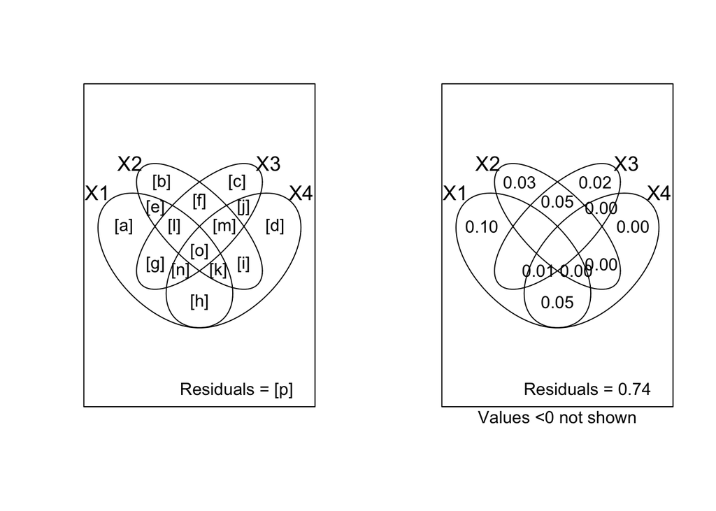

```r
# create pcnm table with only significant axes
endo.pcnm.sub <- scores(endo.pcnm,
                    choices=c(1:4, 6, 11, 14))

# partition variation among four predictor tables:
#   1) leaf species
#   2) leaf type (canopy/litter)
#   3) leaf chemistry
#   4) spatial gradients
endo.var <- varpart(endo.spp,
                    ~ species,
                    ~ type,
                    ~ CNratio + percentN,
                    endo.pcnm.sub, data=endo.env)
#endo.var
par(mfrow=c(1, 2))
showvarparts(4)
plot(endo.var)
```

```r
endo.var
```

```
##
## Partition of variance in RDA
##
## Call: varpart(Y = endo.spp, X = ~species, ~type, ~CNratio +
## percentN, endo.pcnm.sub, data = endo.env)
##
## Explanatory tables:
## X1:  ~species
## X2:  ~type
## X3:  ~CNratio + percentN
## X4:  endo.pcnm.sub
##
## No. of explanatory tables: 4
## Total variation (SS): 39.768
##             Variance: 0.40998
## No. of observations: 98
##
## Partition table:
##                             Df R.square Adj.R.square Testable
## [aeghklno] = X1              8  0.22506      0.15540     TRUE
## [befiklmo] = X2              1  0.07982      0.07023     TRUE
## [cfgjlmno] = X3              2  0.08771      0.06850     TRUE
## [dhijkmno] = X4              7  0.12999      0.06232     TRUE
## [abefghiklmno] = X1+X2       9  0.30449      0.23335     TRUE
## [acefghjklmno] = X1+X3      10  0.30288      0.22276     TRUE
## [adeghijklmno] = X1+X4      15  0.28494      0.15414     TRUE
## [bcefgijklmno] = X2+X3       3  0.13133      0.10360     TRUE
## [bdefhijklmno] = X2+X4       8  0.20846      0.13732     TRUE
## [cdfghijklmno] = X3+X4       9  0.21086      0.13016     TRUE
## [abcefghijklmno] = X1+X2+X3 11  0.34138      0.25714     TRUE
## [abdefghijklmno] = X1+X2+X4 16  0.36195      0.23592     TRUE
## [acdefghijklmno] = X1+X3+X4 17  0.36150      0.22582     TRUE
## [bcdefghijklmno] = X2+X3+X4 10  0.24551      0.15878     TRUE
## [abcdefghijklmno] = All     18  0.39623      0.25866     TRUE
## Individual fractions
## [a] = X1 | X2+X3+X4          8               0.09988     TRUE
## [b] = X2 | X1+X3+X4          1               0.03284     TRUE
## [c] = X3 | X1+X2+X4          2               0.02274     TRUE
## [d] = X4 | X1+X2+X3          7               0.00152     TRUE
## [e]                          0              -0.00422    FALSE
```

[output cut: 24 more lines]

```
## Controlling 1 table X
## [aghn] = X1 | X2             8               0.16312     TRUE
## [aehk] = X1 | X3             8               0.15426     TRUE
## [aegl] = X1 | X4             8               0.09182     TRUE
## [bfim] = X2 | X1             1               0.07795     TRUE
## [beik] = X2 | X3             1               0.03510     TRUE
## [befl] = X2 | X4             1               0.07500     TRUE
## [cfjm] = X3 | X1             2               0.06736     TRUE
## [cgjn] = X3 | X2             2               0.03337     TRUE
## [cfgl] = X3 | X4             2               0.06784     TRUE
## [dijm] = X4 | X1             7              -0.00126     TRUE
## [dhjn] = X4 | X2             7               0.06708     TRUE
## [dhik] = X4 | X3             7               0.06166     TRUE
## ---
## Use function 'rda' to test significance of fractions of interest
```

The (very complicated) plot shows the adjusted $R^2$ values associated with each partition or for overlapping partitions. Although the plot does not compare labels, we can print the object containing the result of the call to and get the relevant information from the ‘Explanatory tables’ and ‘Partition table’ (under ‘Individual fractions’) blocks.

Then we can test the significance of each individual component. Here we use ‘rda’ function since that is how we performed variation partitioning. We test for the effect of each individual component after already accounting for the effect of the other components using the function (note that we need to specify the name of the dataframe for variables named within ).

```r
# significance of partition X1
anova(rda(endo.spp  ~ species + Condition(endo.env$type) +
          + Condition(endo.env$CNratio) + Condition(endo.env$percentN)
          + Condition(endo.pcnm.sub),
          data=endo.env))
```

```
## Permutation test for rda under reduced model
## Permutation: free
## Number of permutations: 999
##
## Model: rda(formula = endo.spp ~ species + Condition(endo.env$type) + +Condition(endo.env$CNratio) + Condition(endo.env$percentN) + Condition(endo.pcnm.sub), data = endo.env)
##          Df Variance      F Pr(>F)
## Model     8 0.061795 2.4652  0.001 ***
## Residual 79 0.247536
## ---
## Signif. codes:  0 '***' 0.001 '**' 0.01 '*' 0.05 '.' 0.1 ' ' 1
```

```r
# significance of partition X2
anova(rda(endo.spp  ~ type + Condition(endo.env$species) +
          + Condition(endo.env$CNratio) + Condition(endo.env$percentN)
          + Condition(endo.pcnm.sub),
          data=endo.env))
```

```
## Permutation test for rda under reduced model
## Permutation: free
## Number of permutations: 999
##
## Model: rda(formula = endo.spp ~ type + Condition(endo.env$species) + +Condition(endo.env$CNratio) + Condition(endo.env$percentN) + Condition(endo.pcnm.sub), data = endo.env)
##          Df Variance      F Pr(>F)
## Model     1 0.014238 4.5438  0.001 ***
## Residual 79 0.247536
## ---
## Signif. codes:  0 '***' 0.001 '**' 0.01 '*' 0.05 '.' 0.1 ' ' 1
```

```r
# significance of partition X3
anova(rda(endo.spp  ~ CNratio + percentN
          + Condition(endo.env$species) + Condition(endo.env$type)
          + Condition(endo.pcnm.sub),
          data=endo.env))
```

```
## Permutation test for rda under reduced model
## Permutation: free
## Number of permutations: 999
##
## Model: rda(formula = endo.spp ~ CNratio + percentN + Condition(endo.env$species) + Condition(endo.env$type) + Condition(endo.pcnm.sub), data = endo.env)
##          Df Variance      F Pr(>F)
## Model     2 0.014053 2.2425  0.001 ***
## Residual 79 0.247536
## ---
## Signif. codes:  0 '***' 0.001 '**' 0.01 '*' 0.05 '.' 0.1 ' ' 1
```

```r
# significance of partition X4
anova(rda(endo.spp  ~ endo.pcnm.sub
          + Condition(endo.env$species) + Condition(endo.env$type)
          + Condition(endo.env$CNratio) + Condition(endo.env$percentN)))
```

```
## Permutation test for rda under reduced model
## Permutation: free
## Number of permutations: 999
##
## Model: rda(formula = endo.spp ~ endo.pcnm.sub + Condition(endo.env$species) + Condition(endo.env$type) + Condition(endo.env$CNratio) + Condition(endo.env$percentN))
##          Df Variance      F Pr(>F)
## Model     7 0.022487 1.0252   0.41
## Residual 79 0.247536
```

Leaf species, type (litter/fresh), and chemistry are all statistically significant in their contributions to fungal community composition, even though the amount of variation explained by some of these variables is small. There was no statistically significant spatial pattern in fungal community composition independent of these other measured drivers.